# LR Generator Vignette

Eshan Hussain

February 25, 2026

This vignette describes how to use the generate_data function to create synthetic data.

## Generating data around a user defined LR equation

The function `generate_data()` adds random noise to y values and generates (x,y) pairs that follows a user-defined relation. It generates random independent `x` variables, computes dependent `y` values using the equation **y = XB + e**, and includes the noise term `e`.

If `save` is TRUE, the function saves the data inside a csv file, else, it returns a dataframe containing an arbitrary amount of x values, y values, and the noise applied to the relation.

## Function Parameters

```markdown
- `num_x`: Number of x variables in the equation. For example, y = 2x + 1 has 1 x value.
- `b_vector`: Vector of coefficients including the intercept. For example, the b vector for y = 2x + 1 is `c(1, 2)`.
- `values`: Number of observations (y values) to generate.
- `sd`: Standard deviation of the error term.
- `save`: Boolean. If `TRUE`, saves output as a CSV file; if `FALSE`, returns a dataframe.
```

## Return Value

On success, the function either returns 0 if `save` is TRUE or a dataframe if `save` is FALSE. Note that the name of the csv file is `output.csv.`In the case where the length of `b_vector` does not equal to `num_x + 1`, the function returns -1 on failure.

## Examples

### Example 1: Save to CSV

The example here generates 50 (x1, y) pairs. Each error follows a normal distribution with mean 0 and standard deviation 0.1. The (x1,y) pairs follow the y=3-2(x1) relation. It saves the result in `output.csv`.

```r
generate_data(num_x = 1, b_vector = c(3, -2), values = 50, sd = 0.1, save = TRUE)
```

```
## [1] 0
```

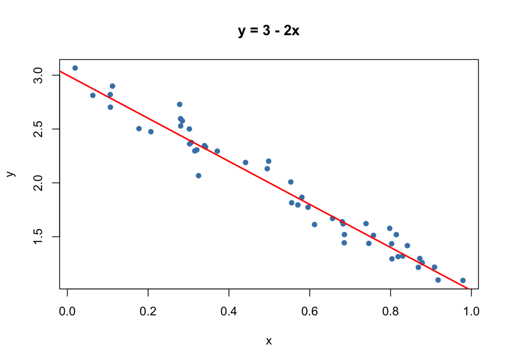

### Example 2: Return as Dataframe

We can create a new relation y=2x+1 and save it as a dataframe. We do this by setting `save` to FALSE. For this example, we will create 10 data points.

```r
generate_data(num_x = 1, b_vector = c(1, 2), values = 10, sd = 0.1, save = FALSE)
```

```
##            x1        y         noise
## 1  0.16839759 1.262908 -0.0738873598
## 2  0.16434389 1.258934 -0.0697542137
## 3  0.69941074 2.582069  0.1832472115
## 4  0.79086640 2.559260 -0.0224723516
## 5  0.03137306 1.063519  0.0007733471
## 6  0.37405431 1.674677 -0.0734316923
## 7  0.89239972 2.690814 -0.0939852967
## 8  0.16481823 1.404037  0.0744009245
## 9  0.46155072 2.108772  0.1856708804
## 10 0.69020005 2.442819  0.0624186142
```

### Example 3: Multiple X Variables

You can generate data with multiple independent variables by increasing `num_x` and providing the appropriate number of coefficients. For instance, the example below generates data for this relation: y=1+2(x1)-(x2)

```r
df_multi <- generate_data(num_x = 2, b_vector = c(1, 2, -1), values = 100, sd = 0.5, save = FALSE)
head(df_multi)
```

```
##           x1         x2         y        noise
## 1 0.82553812 0.04988576 3.0365459  0.435355409
## 2 0.38751716 0.80571079 0.7207388 -0.248584704
## 3 0.26027220 0.40493577 1.3418039  0.226195222
## 4 0.15777854 0.27546173 0.4090826 -0.631012740
## 5 0.97884753 0.33474394 2.6261283  0.003177184
## 6 0.05292152 0.19985343 0.9174645  0.011474918
```

## Citations

sanchez, A. nosedal. (n.d.). sta302-classical-SLR-assumptions. Lecture. Mississauga: University of Toronto.

sanchez, A. nosedal. (n.d.). sta302-estimation-and-GM-thm. Lecture. Mississauga: University of Toronto.

sanchez, A. nosedal. (n.d.). sta302-slr-in-matrix-terms. Lecture. Mississauga: University of Toronto.